# Problem Statement

## Context & Objectives

In recent times, the field of agriculture has been in urgent need of modernizing, since the amount of manual work people need to put in to check if plants are growing correctly is still highly extensive. Despite several advances in agricultural technology, people working in the agricultural industry still need to have the ability to sort and recognize different plants and weeds, which takes a lot of time and effort in the long term. The potential is ripe for this trillion-dollar industry to be greatly impacted by technological innovations that cut down on the requirement for manual labor, and this is where Artificial Intelligence can actually benefit the workers in this field, as the time and energy required to identify plant seedlings will be greatly shortened by the use of AI and Deep Learning. The ability to do so far more efficiently and even more effectively than experienced manual labor, could lead to better crop yields, the freeing up of human inolvement for higher-order agricultural decision making, and in the long term will result in more sustainable environmental practices in agriculture as well.

**Objective**

The aim of this project is to Build a Convolutional Neural Netowrk to help classify plant seedlings from images into their respective categories, that way leveraging the power of AI to ease the burden of this type of manual work.

**How are we measuring success?**

Given the use case, we will be focusing ourselves more on aspects of accuracy, while still putting emphasis on precision and recall.

## Data Dictionary

The Aarhus University Signal Processing group, in collaboration with the University of Southern Denmark, has recently released a dataset containing images of unique plants belonging to 12 different species.

**List of Species**

- Black-grass
- Charlock
- Cleavers
- Common Chickweed
- Common Wheat
- Fat Hen
- Loose Silky-bent
- Maize
- Scentless Mayweed
- Shepherds Purse
- Small-flowered Cranesbill
- Sugar beet

# Importing Libraries

```python
# Installing the libraries with the specified version.
# uncomment and run the following line if Google Colab is being used
# !pip install tensorflow==2.15.0 scikit-learn==1.2.2 seaborn==0.13.1 matplotlib==3.7.1 numpy==1.25.2 pandas==1.5.3 opencv-python==4.8.0.76 -q --user
```

```python
# Installing the libraries with the specified version.
# uncomment and run the following lines if Jupyter Notebook is being used
#!pip install tensorflow==2.13.0 scikit-learn==1.2.2 seaborn==0.11.1 matplotlib==3.3.4 numpy==1.24.3 pandas==1.5.2 opencv-python==4.8.0.76 -q --user
```

```python
import os # interacting with the operating system, including file operations and environment variables
import numpy as np # matrix Operations
import pandas as pd # read CSV files
import matplotlib.pyplot as plt # plotting and visualizing images
import math # perform mathematical operations
import cv2 # image processing
import seaborn as sns #plot graphs


# Tensorflow modules
import tensorflow as tf
from tensorflow.keras.preprocessing.image import ImageDataGenerator # data augmentation
from tensorflow.keras.models import Sequential # sequential model
from tensorflow.keras.layers import Dense,Dropout,Flatten,Conv2D,MaxPooling2D,BatchNormalization,Activation # layers for CNN Model building
from tensorflow.keras.optimizers import Adam,SGD # importing optimizers
from tensorflow.keras import backend # importing backend module
from keras.callbacks import ReduceLROnPlateau # dynamically reducing learning rate on plateau
from tensorflow.keras.callbacks import EarlyStopping  #regularization method to prevent the overfitting
from tensorflow.keras.callbacks import ModelCheckpoint
from sklearn import preprocessing # preprocess the data
from sklearn.model_selection import train_test_split # train_test_split function
from sklearn.metrics import confusion_matrix # confusion_matrix
from sklearn.preprocessing import LabelBinarizer # converting categorical labels into binary vectors
import random # generating random numbers and performing random operations


# Display images using OpenCV
from google.colab.patches import cv2_imshow # cv2_imshow from google.patches to display images


# Ignore warnings
import warnings
warnings.filterwarnings('ignore')
```

# Loading the Dataset

```python
# mounting the drive
from google.colab import drive
drive.mount('/content/drive')
```

```python
# Loading the image file of dataset
images = np.load('/content/drive/MyDrive/pgp_aiml/computer_vision/cv_images.npy')

# Loading the labels file of dataset
labels = pd.read_csv('/content/drive/MyDrive/pgp_aiml/computer_vision/cv_labels.csv')
```

# Overview of the Dataset

```python
# Observing the shape of imported images and labels
print(images.shape)
print(labels.shape)
```

```
(4750, 128, 128, 3)
(4750, 1)
```

There are 4750 images of shape 128x128x3, each image having 3 channels

# Exploratory Data Analysis

#### Observing Labels

```python
# Observing labels in the dataset
labels
```

|  | Label |
| --- | --- |
| 0 | Small-flowered Cranesbill |
| 1 | Small-flowered Cranesbill |
| 2 | Small-flowered Cranesbill |
| 3 | Small-flowered Cranesbill |
| 4 | Small-flowered Cranesbill |
| ... | ... |
| 4745 | Loose Silky-bent |
| 4746 | Loose Silky-bent |
| 4747 | Loose Silky-bent |
| 4748 | Loose Silky-bent |
| 4749 | Loose Silky-bent |

4750 rows × 1 columns

#### Converting Numpy Arrays & Visualizing Random Images

```python
# Visualizing a set of images along with their corresponding labels
def plot_images(images,labels):
  num_classes = len(np.unique(labels)) # number of unique classes in the dataset
  categories=np.unique(labels) # array containing unique classes
  keys=dict(labels['Label']) # obtaining the unique classes from y_train
  rows = 3 # defining 3 rows
  cols = 4 # defining 4 columns
  fig = plt.figure(figsize=(10, 8)) # size of the figure to 10x8 inches
  for i in range(cols):
      for j in range(rows):
          random_index = np.random.randint(0, len(labels))
          ax = fig.add_subplot(rows, cols, i * rows + j + 1)
          ax.imshow(images[random_index, :])
          ax.set_title(keys[random_index])
  plt.show()
```

Converting NumPy arrays into images using the matplotlib **imshow** function. This step allows for ease of visualization, supports the understanding of data distribution, ensures the observation of potential issues, as well as it allows us to gain insight into the patterns and features presented in the dataset.

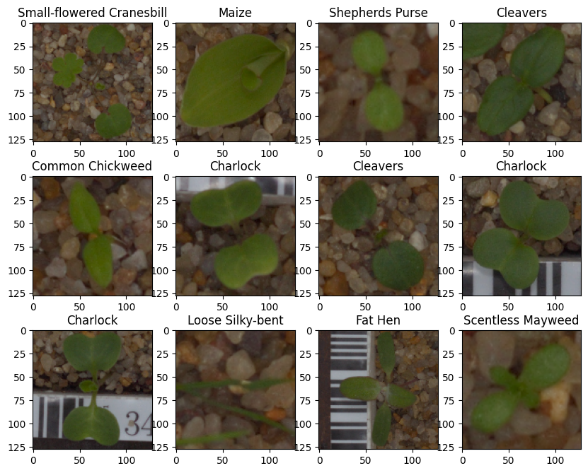

```python
# Image plot to visualize the images in our dataset
plot_images(images,labels)
```

Our dataset comprises a diverse collection of images featuring plant seedlings, each captured at varying resolutions and against different backgrounds. This variability necessitates robust training of our model to effectively distinguish and classify these seedlings into their respective categories. By training on such varied data, our objective is to develop a CNN capable of accurately identifying and categorizing each seedling type based on its visual characteristics. This entails overcoming challenges such as differing image resolutions and backgrounds, ensuring that our model's learning encompasses the breadth of conditions under which these seedlings may be photographed. Through this approach, we aim to achieve a high level of accuracy and reliability in the classification of plant seedlings, leveraging the power of artificial intelligence to streamline and enhance this categorization process.

#### Observing Data Imbalance

[output not shown]

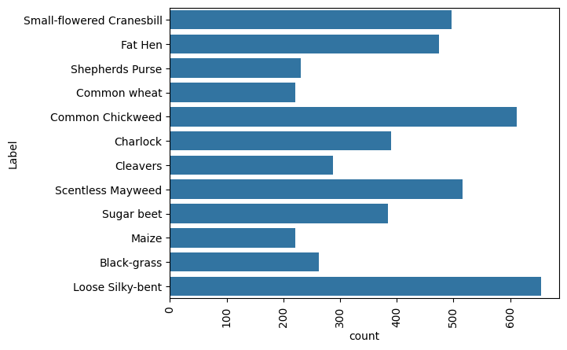

```python
# Countplot to visualize distribution in each category
 sns.countplot(labels['Label'])
 plt.xticks(rotation='vertical')
```

The dataset presents a significant imbalance worth noting, as follows:

- We're observing a larger representation of data for the `Loose Silky-bent` seedling with over 600 counts, the `Common Chickweed` with 600 counts, and the `Scentless Mayweed`, the `Small-flowered Cranesbill`, and the `Fat Hen` in the or close to 500 counts.
- `Charlock` and `Sugar beet` nearing 400, `Cleavers` and `Balack-grass` in the or close to 300 respectively, with the remaining nearing 200 count.

This imbalance can lead to biased models that are overly proficient at predicting the majority class while performing poorly on minority classes. Consequently, the model's overall accuracy may appear satisfactory, but its performance on less frequent classes can be inadequate, leading to misclassification and reduced generalization in real-world scenarios. Addressing data imbalance is crucial, as it ensures that the model learns to recognize and correctly classify all categories, enhancing its robustness and reliability.

# Data Pre-Processing

#### Plotting images using OpenCV and Matplotlib

```python
# Visualizing using OpenCV
cv2_imshow(images[5])
```

[output not shown]

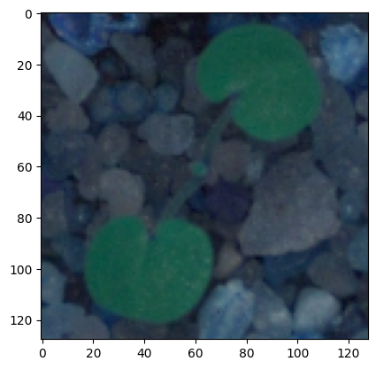

```python
# Visualizing using Matplotlib
plt.imshow(images[5])
```

- When visualizing the images using both OpenCV and Matplotlib, a noticeable difference in color representation is observed. This discrepancy arises because OpenCV reads images in the BGR (Blue, Green, Red) format, whereas Matplotlib typically expects images in the RGB (Red, Green, Blue) format. This distinction suggests that the numpy arrays provided for plotting were generated from the original images using OpenCV.
- Now we will convert these BGR images to RGB images so to interpret them more easily.

#### Converting BGR to RGB images

```python
# Converting the images from BGR to RGB using OpenCV cvtColor function
for i in range(len(images)):
  images[i] = cv2.cvtColor(images[i], cv2.COLOR_BGR2RGB)
```

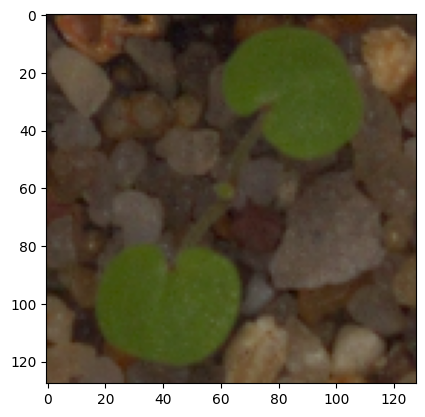

```python
# Confirming conversion
plt.imshow(images[5])
```

Converting from BGR (Blue-Green-Red) to RGB (Red-Green-Blue) color channels is crucial in image processing tasks, particularly when working with libraries or frameworks that expect RGB format, such as most deep learning frameworks and visualization tools. BGR and RGB represent different ordering of color channels in an image. In BGR, the order of channels is blue, green, and red, whereas in RGB, it's red, green, and blue. Many image processing libraries, including OpenCV, typically read images in BGR format by default. However, for tasks like deep learning where RGB is the standard, converting images to RGB ensures compatibility with models and avoids potential color channel mismatch errors. This conversion ensures that the model interprets colors correctly, leading to accurate predictions and reliable performance in image classification, object detection, and other computer vision applications.

#### Resizing Images

```python
# Setting image height and width to 64
images_decreased=[]
height = 64
width =  64
dimensions = (width, height)
for i in range(len(images)):
  images_decreased.append( cv2.resize(images[i], dimensions, interpolation=cv2.INTER_LINEAR))
```

As the size of the images is large, it may be computationally expensive to train on these larger images. It is therefore preferable to reduce the image size from 128 to 64.

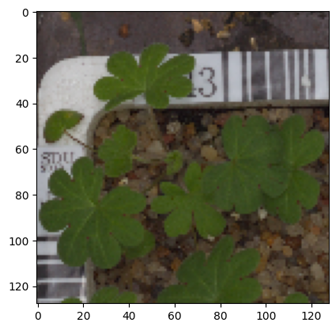

```python
# Displaying image before resizing
plt.imshow(images[3])
```

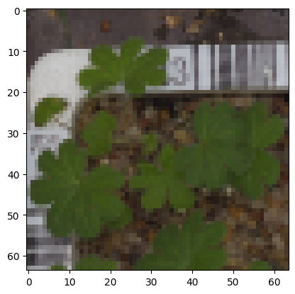

```python
# Displaying image after resizing
plt.imshow(images_decreased[3])
```

[figure not shown]

```python
# Generating a plot to help visualize against a sample
plot_images(np.array(images_decreased),labels)
```

##### Experimenting with Gaussian Blur

```python
# Applying Gaussian Blur to denoise the images
images_gb=[]
for i in range(len(images)):
  # gb[i] = cv2.cvtColor(images[i], cv2.COLOR_BGR2RGB)
  images_gb.append(cv2.GaussianBlur(images[i], ksize =(3,3),sigmaX =  0))
```

```python
plt.imshow(images_gb[3])
```

[output not shown]

```python
plot_images(np.array(images_gb),labels)
```

[output not shown]

# Data Preparation for Modeling

#### Data Splitting

```python
from sklearn.model_selection import train_test_split

# Splitting data into 70% train and 30% temporary set
X_train, X_temp, y_train, y_temp = train_test_split(np.array(images_decreased), labels, test_size=0.3, random_state=42, stratify=labels)

# Splitting temporary set into test and validation sets (50/50 split for validation and testing)
X_test, X_val, y_test, y_val = train_test_split(X_temp, y_temp, test_size=0.5, random_state=42, stratify=y_temp)
```

```python
print(X_train.shape,y_train.shape)
print(X_val.shape,y_val.shape)
print(X_test.shape,y_test.shape)
```

```
(3325, 64, 64, 3) (3325, 1)
(713, 64, 64, 3) (713, 1)
(712, 64, 64, 3) (712, 1)
```

- We have 4750 data points allowing us to split the data into train, validation and test for proper representation of the dataset.
- Opting for a 70:30 original split as it offers a larger set to support more reliable assessments in the validation set and further model generalization in test.
- Setting shuffle parameter to true to ensure data is randomly shuffled before splitting, helping prevent any inherent order or patterns in the data from biasing the splits.
- maintaining class stratification through the stratify parameter, crucial for unbalanced datasets.

#### Encoding Target Variable

```python
# Converting labels from names to one hot vectors
from sklearn.preprocessing import LabelBinarizer
enc = LabelBinarizer()

y_train_encoded = enc.fit_transform(y_train)
y_val_encoded=enc.transform(y_val)
y_test_encoded=enc.transform(y_test)
```

```python
# Checking the shapes of the encoded labels for training, validation, and test sets
y_train_encoded.shape,y_val_encoded.shape,y_test_encoded.shape
```

```
((3325, 12), (713, 12), (712, 12))
```

Encoding ensures that the target variable is in a format that facilitates the learning process, allowing the model to accurately capture the relationships between the input features and the target labels.

#### Data Normalization

Normalization makes the training faster and reduces the chances of getting stuck at local optima. In deep neural networks, normalization helps to avoid exploding gradient problems. Gradient exploding problem occurs when large error gradients accumulate and result in very large updates to neural network model weights during training. This makes a model unstable and unable to learn from the training data.

```python
# Normalizing the image pixels
X_train_normalized = X_train.astype('float32')/255.0
X_val_normalized = X_val.astype('float32')/255.0
X_test_normalized = X_test.astype('float32')/255.0
```

Since the image pixel values range from 0-255, our method of normalization here will be scaling - we shall divide all the pixel values by 255 to standardize the images to have values between 0-1.

# Model Building

```python
# Clearing backend
backend.clear_session()
```

```python
# Code to monitor val_accuracy
learning_rate_reduction = ReduceLROnPlateau(monitor='val_accuracy',
                                            patience=3,
                                            verbose=1,
                                            factor=0.5,
                                            min_lr=0.00001)
```

```python
# Setting the seed for random number generators
import random
np.random.seed(42)
random.seed(42)
tf.random.set_seed(42)
```

Setting the seed for random number generators is crucial for reproducibility in experiments.

```python
# Intializing a sequential model
model1 = Sequential()

# First layer with 32 filters and kernel size 3x3, padding set to 'same' to provide the same output size as the input size
model1.add(Conv2D(64, (3, 3), activation='relu', padding="same", input_shape=(64, 64, 3))) # input_shape set to the image dimensions
model1.add(MaxPooling2D((2, 2), padding = 'same')) # Adding max pooling to reduce the size of output of first layer

model1.add(Conv2D(32, (3, 3), activation='relu', padding="same")) # experimenting with a second layer
model1.add(MaxPooling2D((2, 2), padding='same'))

model1.add(Conv2D(32, (3, 3), activation='relu', padding="same")) # experimenting with a third layer
model1.add(MaxPooling2D((2, 2), padding='same'))

# Flattening the layer's output to make it ready for creating dense connections
model1.add(Flatten())

# Fully connected dense layers
model1.add(Dense(200, activation='relu'))
model1.add(Dropout(0.2)) # addding dropout to help reduce overfitting
model1.add(Dense(200, activation='relu'))

# Adding the output layer with 12 neurons and activation functions as softmax since this is a multi-class classification problem
model1.add(Dense(12, activation='softmax'))

# Using Adam Optimizer
opt = Adam()

# Compile model
model1.compile(optimizer=opt, loss='categorical_crossentropy', metrics=['accuracy']) # selecting categorical_crossentropy as the loss function and 'accuracy' as the key metric
```

- Choosing Max Pooling for its ability to reduce spatial dimensions and retaining the most prominent features, therefore encouraging the model to learn more robust and generalized features that are less sensitive to the exact details or noise in the input.
- The Adam optimizer (opt) is chosen for its adaptive learning rate method particularly on its effectiveness in optimizing models for tasks such as multi-class classification.
- For multi-class classification tasks, categorical_crossentropy is a widely used loss function for its ability to directly optimize for probabilities, allowing for the model to learn to assign higher probabilities to the correct class labels - essential for accurate classification.
- The chosen metrics was set to 'accuracy' as our primary goal lies on ensuring that the model can accurately classify the seedlings. With that said, we want to emphasize the importance of observing other metrics such as 'precision', and 'recall' - particularly relevant for this case where class imbalance is observed.

```python
# Printing the model summary
model1.summary()
```

```
Model: "sequential"
_________________________________________________________________
 Layer (type)                Output Shape              Param #
=================================================================
 conv2d (Conv2D)             (None, 64, 64, 64)        1792

 max_pooling2d (MaxPooling2  (None, 32, 32, 64)        0
 D)

 conv2d_1 (Conv2D)           (None, 32, 32, 32)        18464

 max_pooling2d_1 (MaxPoolin  (None, 16, 16, 32)        0
 g2D)

 conv2d_2 (Conv2D)           (None, 16, 16, 32)        9248

 max_pooling2d_2 (MaxPoolin  (None, 8, 8, 32)          0
 g2D)

 flatten (Flatten)           (None, 2048)              0

 dense (Dense)               (None, 200)               409800

 dropout (Dropout)           (None, 200)               0

 dense_1 (Dense)             (None, 200)               40200

 dense_2 (Dense)             (None, 12)                2412

=================================================================
Total params: 481916 (1.84 MB)
Trainable params: 481916 (1.84 MB)
Non-trainable params: 0 (0.00 Byte)
_________________________________________________________________
```

#### Fitting the Model on Training Data

```python
# Fitting the model
history_1 = model1.fit(
            X_train_normalized, y_train_encoded,
            epochs=15,
            validation_data=(X_val_normalized,y_val_encoded),
            shuffle = True,
            batch_size=64,
            verbose=2,
)
```

```
52/52 - 2s - loss: 2.4138 - accuracy: 0.1564 - val_loss: 2.2391 - val_accuracy: 0.2525 - 2s/epoch - 43ms/step
52/52 - 0s - loss: 1.8948 - accuracy: 0.3411 - val_loss: 1.6271 - val_accuracy: 0.4250 - 316ms/epoch - 6ms/step
52/52 - 0s - loss: 1.5746 - accuracy: 0.4247 - val_loss: 1.4777 - val_accuracy: 0.4614 - 304ms/epoch - 6ms/step
52/52 - 0s - loss: 1.4270 - accuracy: 0.4788 - val_loss: 1.3515 - val_accuracy: 0.5105 - 320ms/epoch - 6ms/step
52/52 - 0s - loss: 1.2548 - accuracy: 0.5648 - val_loss: 1.1876 - val_accuracy: 0.6003 - 306ms/epoch - 6ms/step
52/52 - 0s - loss: 1.0489 - accuracy: 0.6349 - val_loss: 0.9882 - val_accuracy: 0.6746 - 303ms/epoch - 6ms/step
52/52 - 0s - loss: 0.9443 - accuracy: 0.6758 - val_loss: 0.9213 - val_accuracy: 0.7055 - 306ms/epoch - 6ms/step
52/52 - 0s - loss: 0.8596 - accuracy: 0.6965 - val_loss: 0.9558 - val_accuracy: 0.6872 - 306ms/epoch - 6ms/step
52/52 - 0s - loss: 0.7900 - accuracy: 0.7266 - val_loss: 0.8535 - val_accuracy: 0.7027 - 309ms/epoch - 6ms/step
52/52 - 0s - loss: 0.7007 - accuracy: 0.7498 - val_loss: 0.8253 - val_accuracy: 0.7377 - 304ms/epoch - 6ms/step
52/52 - 0s - loss: 0.6897 - accuracy: 0.7603 - val_loss: 0.8052 - val_accuracy: 0.7447 - 315ms/epoch - 6ms/step
52/52 - 0s - loss: 0.6028 - accuracy: 0.7877 - val_loss: 0.8876 - val_accuracy: 0.7097 - 306ms/epoch - 6ms/step
52/52 - 0s - loss: 0.5357 - accuracy: 0.8117 - val_loss: 0.7846 - val_accuracy: 0.7518 - 302ms/epoch - 6ms/step
52/52 - 0s - loss: 0.4995 - accuracy: 0.8292 - val_loss: 0.7493 - val_accuracy: 0.7686 - 309ms/epoch - 6ms/step
52/52 - 0s - loss: 0.4582 - accuracy: 0.8418 - val_loss: 0.7042 - val_accuracy: 0.7784 - 315ms/epoch - 6ms/step
```

#### Model Evaluation

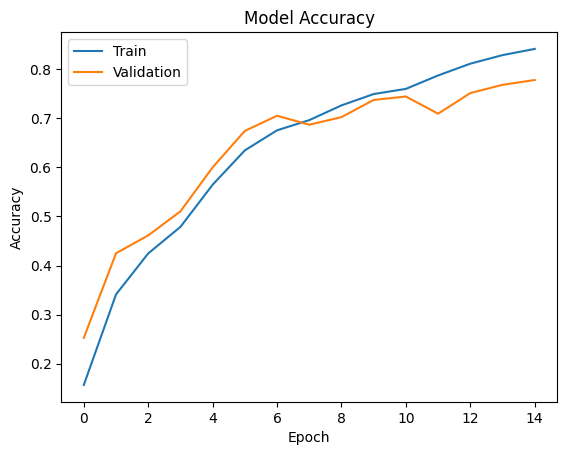

```python
# Creating a plot to visualize model accuracy
plt.plot(history_1.history['accuracy'])
plt.plot(history_1.history['val_accuracy'])
plt.title('Model Accuracy')
plt.ylabel('Accuracy')
plt.xlabel('Epoch')
plt.legend(['Train', 'Validation'], loc='upper left')
plt.show()
```

```python
# Evaluating the model on test data
accuracy = model1.evaluate(X_test_normalized, y_test_encoded, verbose=2)
```

```
23/23 - 0s - loss: 0.6679 - accuracy: 0.7837 - 80ms/epoch - 3ms/step
```

#### Plotting the Confusion Matrix

```python
# Predicting the output probability
y_pred_1=model1.predict(X_test_normalized)
```

```python
# Extracting predicted class labels from probability distribution
y_pred_arg_1=np.argmax(y_pred_1,axis=1)
y_pred_arg_1
```

```
array([ 5, 10,  8, 11, 11,  6,  1,  8,  7, 11,  3,  3,  5,  1,  1,  8,  2,
        9,  3, 11,  6,  5,  1,  9,  6,  3,  8,  6, 11,  6, 10,  5,  2,  5,
        8, 11,  5, 11, 10,  3,  6,  6,  8,  2,  3,  3,  1,  5,  6,  6, 10,
       10,  9,  8,  2,  3,  3,  6,  1,  2,  3,  6,  9,  2,  3,  1,  6, 11,
        6,  3,  3,  5,  6,  8, 10,  2,  6,  8,  3, 10,  6, 11,  8,  1,  5,
        8, 11, 10, 11,  9, 11,  8,  5,  7,  6,  8,  2,  2,  3,  1, 10,  6,
        6,  1, 10,  8,  6,  8,  1,  6,  4, 10, 11,  6,  0,  6,  6,  5,  2,
        3, 11, 10,  8,  3,  2,  6,  5,  6,  6,  8,  6,  1,  9,  5,  3,  1,
        1,  0,  3, 10,  6,  6,  6,  8,  6,  8,  2,  3,  6, 11,  4,  6,  6,
        6,  4,  6,  8, 11,  5,  2,  1,  6,  8, 10,  6,  1, 11,  6,  1,  6,
        9, 10,  3, 11,  5,  8,  3, 11,  2,  1,  8,  5,  8,  6,  1, 10,  5,
        8, 10,  8,  7,  6,  7,  7,  1, 10,  6,  3, 10,  1, 10,  3,  1,  2,
        8,  1, 10,  3,  8,  3,  7,  2, 11,  3, 10, 10,  1,  8,  5, 11,  5,
        5,  8,  5,  8,  1,  6,  5,  5,  5,  8,  4,  2,  8,  0,  2, 10, 10,
        3,  1,  3,  3,  6,  2,  3,  6,  3,  7,  8,  0,  4, 10,  6,  9,  1,
```

[output cut: 27 more lines]

```python
# Extracting true class labels from encoded format
y_test_arg_1=np.argmax(y_test_encoded,axis=1)
y_test_arg_1
```

```
array([ 5, 10,  8, 11, 10,  6,  1,  8, 10, 11,  3,  8,  7,  1,  1,  7,  5,
        9,  3, 11,  6,  5,  5,  9,  5,  8,  8,  4, 11,  0, 10,  5,  2,  5,
        8, 11,  5, 11, 10,  3,  6,  6, 10,  2,  3,  3,  1,  4,  0,  6, 10,
       11, 11,  9,  2,  3,  3,  6,  1,  8,  3,  0,  9,  2,  3,  1,  6, 11,
        4,  3,  3,  5,  6,  9, 10,  2,  6,  8,  3, 10,  6, 11,  8,  1,  4,
        8, 11, 10, 11,  8, 11, 11,  4,  7,  6,  8,  2,  2,  3,  1, 10,  6,
        6,  1, 10,  8,  6,  4,  1,  0,  4, 11, 11,  6,  4,  0,  6,  5,  2,
        3, 11,  1,  8,  3,  2,  6,  5,  6,  0, 11,  6,  1,  9,  5,  3,  1,
        1,  6,  3, 10,  6,  4,  6,  8,  8,  5,  2,  9,  4, 11,  4,  6,  0,
        6,  8,  6,  5, 11,  7,  2,  1,  5,  8, 10,  4,  1, 11,  6,  2,  6,
        9, 10,  3, 11,  5,  8,  3, 11,  2,  1,  8,  5,  8,  6,  1, 10,  5,
        5, 10,  8, 11,  6,  7,  7,  1, 10,  6,  3, 11,  8, 10,  3,  1,  1,
        8,  1, 10,  3,  8,  3, 10,  2,  5,  3,  9, 10,  1,  8,  5, 11,  5,
        5,  9,  0,  8,  1,  6,  4,  5,  5,  8,  4,  2,  8,  0,  2,  9, 10,
        3,  1,  3,  3,  6, 10,  3,  0,  3,  7,  7,  0,  4, 10,  6,  9,  1,
```

[output cut: 27 more lines]

- The Confusion matrix expects the input to be of categorical values. However, the y_test_encoded is an encoded value, whereas y_pred has probabilities. So, we must retrieve the categorical values back from the encoded values.
- We will use the `argmax()` function to obtain the maximum value over each category on both y_test_encoded and y_pred and obtain their respective classes.

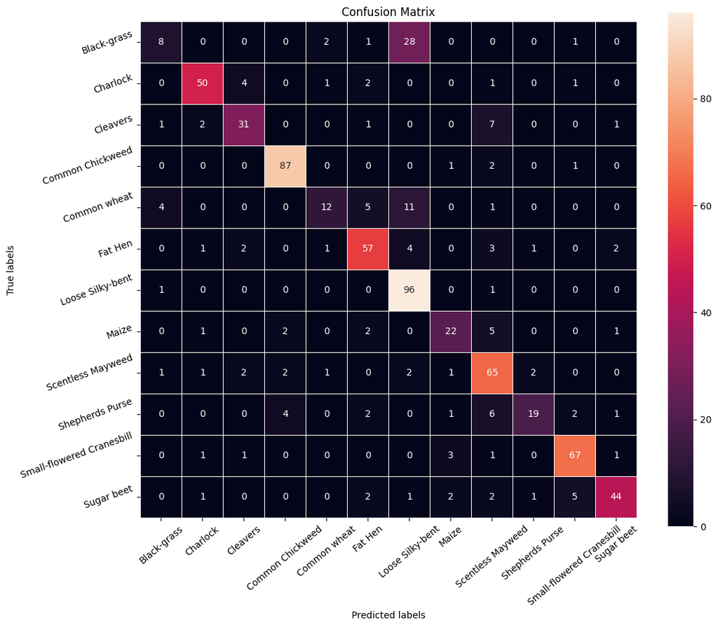

```python
from sklearn import metrics

# Plotting the Confusion Matrix
confusion_matrix = tf.math.confusion_matrix(y_test_arg_1,y_pred_arg_1)
f, ax = plt.subplots(figsize=(12, 10))
sns.heatmap(
    confusion_matrix,
    annot=True,
    linewidths=.4,
    fmt="d",
    square=True,
    ax=ax,
)

# Setting the labels to both the axes
ax.set_xlabel('Predicted labels');ax.set_ylabel('True labels');
ax.set_title('Confusion Matrix');
ax.xaxis.set_ticklabels(list(enc.classes_),rotation=40)
ax.yaxis.set_ticklabels(list(enc.classes_),rotation=20)
plt.show()
```

The confusion matrix serves to illustrate the predicted versus actual classifications, highlighting how accurately the model identifies different classes. In this case, there's a noticeable pattern where the model tends to misclassify classes with fewer instances, and at times even mislabel them as those with more instances.

- Black Grass, Cleavers, Common Wheat, Maize, Sheperds Purse are particularly misclassified
- Common Chickweed and Loose Silky-Bent are particularly well classified (not coincidently, the two classes with best representation in our dataset)

```python
# Plotting the classification report
cr_model_1=metrics.classification_report(y_test_arg_1,y_pred_arg_1)
print(cr_model_1)
```

```
              precision    recall  f1-score   support

           0       0.53      0.20      0.29        40
           1       0.88      0.85      0.86        59
           2       0.78      0.72      0.75        43
           3       0.92      0.96      0.94        91
           4       0.71      0.36      0.48        33
           5       0.79      0.80      0.80        71
           6       0.68      0.98      0.80        98
           7       0.73      0.67      0.70        33
           8       0.69      0.84      0.76        77
           9       0.83      0.54      0.66        35
          10       0.87      0.91      0.89        74
          11       0.88      0.76      0.81        58

    accuracy                           0.78       712
   macro avg       0.77      0.72      0.73       712
weighted avg       0.78      0.78      0.77       712
```

Based on the provided classification report, the model achieves varying levels of precision, recall, and F1-score across different classes. Notably, classes 3 (precision: 0.92, recall: 0.96, F1-score: 0.94), 10 (precision: 0.87, recall: 0.91, F1-score: 0.89), and 11 (precision: 0.88, recall: 0.76, F1-score: 0.81) exhibit higher performance metrics, indicating strong predictive capability for these classes. Conversely, classes 0 (precision: 0.53, recall: 0.20, F1-score: 0.29) and 4 (precision: 0.71, recall: 0.36, F1-score: 0.48) show lower performance, suggesting challenges in correctly predicting these classes. Overall, with an accuracy of 0.78, the model demonstrates reasonable effectiveness across the dataset, but improvements could be made, particularly in enhancing predictions for classes with lower precision and recall scores.

# Model Performance Improvement

## Data Augmentation

```python
# Clearing backend
from tensorflow.keras import backend
backend.clear_session()
```

```python
# Fixing the seed for random number generators
import random
np.random.seed(42)
random.seed(42)
tf.random.set_seed(42)
```

```python
# Increasing the diversity of the training sample
train_datagen = ImageDataGenerator(
                              horizontal_flip = True,
                              vertical_flip = True,
                              height_shift_range= 0.1,
                              width_shift_range=0.1,
                              rotation_range=20,
                              shear_range = 0.1,
                              zoom_range=0.1,
                              fill_mode='nearest' # value of each new pixel is copied from the closest pixel in the original image
                              )
```

The parameters chosen for the train_datagen ImageDataGenerator are designed to enhance the robustness and generalization capability of the deep learning model during training. Horizontal and vertical flips (horizontal_flip=True, vertical_flip=True) increase the diversity of training samples, helping the model generalize better to unseen data orientations. The height_shift_range and width_shift_range parameters (both set to 0.1) allow for random shifts of up to 10% of the image height and width, respectively, augmenting the dataset with slightly translated versions of the images. A rotation_range of 20 degrees introduces variability by randomly rotating images within this range, while shear_range of 0.1 applies shearing transformations to simulate perspective changes. The zoom_range of 0.1 randomly zooms into images by up to 10%, adding more variability. Finally, fill_mode='nearest' ensures that any newly created pixels are filled with values from the nearest existing pixels, maintaining the image's overall appearance. Together, these parameter choices aim to improve the model's ability to generalize by exposing it to a wide variety of augmented training examples, thereby enhancing its robustness and performance on unseen data.

```python
# Intializing a sequential model
model2 = Sequential()

# First layer with 64 filters and kernel size 3x3, padding set to 'same' to provide the same output size as the input size
model2.add(Conv2D(64, (3, 3), activation='relu', padding="same", input_shape=(64, 64, 3))) # input_shape set to the image dimensions
model2.add(MaxPooling2D((2, 2), padding = 'same')) # Adding max pooling to reduce the size of output of first layer

model2.add(Conv2D(32, (3, 3), activation='relu', padding="same"))
model2.add(MaxPooling2D((2, 2), padding='same'))

model2.add(Conv2D(32, (3, 3), activation='relu', padding="same"))
model2.add(MaxPooling2D((2, 2), padding='same'))

# Flattening the layer's output to make it ready for creating dense connections
model2.add(Flatten())

# Fully connected dense layers
model2.add(Dense(200, activation='relu'))
model2.add(Dropout(0.2))
model2.add(Dense(200, activation='relu'))

# Adding the output layer with 12 neurons and activation functions as softmax since this is a multi-class classification problem
model2.add(Dense(12, activation='softmax'))

# Using Adam Optimizer
opt = Adam()

# Compile model
model2.compile(optimizer=opt, loss='categorical_crossentropy', metrics=['accuracy']) # selecting categorical_crossentropy as the loss function and 'accuracy' as the key metric
```

```python
# Printing the model summary
model2.summary()
```

```
Model: "sequential"
_________________________________________________________________
 Layer (type)                Output Shape              Param #
=================================================================
 conv2d (Conv2D)             (None, 64, 64, 64)        1792

 max_pooling2d (MaxPooling2  (None, 32, 32, 64)        0
 D)

 conv2d_1 (Conv2D)           (None, 32, 32, 32)        18464

 max_pooling2d_1 (MaxPoolin  (None, 16, 16, 32)        0
 g2D)

 conv2d_2 (Conv2D)           (None, 16, 16, 32)        9248

 max_pooling2d_2 (MaxPoolin  (None, 8, 8, 32)          0
 g2D)

 flatten (Flatten)           (None, 2048)              0

 dense (Dense)               (None, 200)               409800

 dropout (Dropout)           (None, 200)               0

 dense_1 (Dense)             (None, 200)               40200

 dense_2 (Dense)             (None, 12)                2412

=================================================================
Total params: 481916 (1.84 MB)
Trainable params: 481916 (1.84 MB)
Non-trainable params: 0 (0.00 Byte)
_________________________________________________________________
```

```python
# Fitting the model
history_2 = model2.fit(
            train_datagen.flow(X_train_normalized, y_train_encoded),
            epochs=30,
            validation_data=(X_val_normalized,y_val_encoded),
            batch_size=64,
            shuffle = True,
            verbose=2, callbacks=[learning_rate_reduction]
)
```

```
104/104 - 4s - loss: 0.7261 - accuracy: 0.7456 - val_loss: 0.5575 - val_accuracy: 0.7994 - lr: 0.0010 - 4s/epoch - 38ms/step
104/104 - 4s - loss: 0.6763 - accuracy: 0.7612 - val_loss: 0.5140 - val_accuracy: 0.8303 - lr: 0.0010 - 4s/epoch - 37ms/step
104/104 - 4s - loss: 0.6593 - accuracy: 0.7657 - val_loss: 0.5462 - val_accuracy: 0.8191 - lr: 0.0010 - 4s/epoch - 37ms/step
104/104 - 4s - loss: 0.6454 - accuracy: 0.7756 - val_loss: 0.4780 - val_accuracy: 0.8527 - lr: 0.0010 - 4s/epoch - 37ms/step
104/104 - 4s - loss: 0.6207 - accuracy: 0.7916 - val_loss: 0.4831 - val_accuracy: 0.8401 - lr: 0.0010 - 4s/epoch - 36ms/step
104/104 - 4s - loss: 0.6239 - accuracy: 0.7759 - val_loss: 0.5106 - val_accuracy: 0.8149 - lr: 0.0010 - 4s/epoch - 37ms/step

Epoch 7: ReduceLROnPlateau reducing learning rate to 0.0005000000237487257.
104/104 - 4s - loss: 0.5882 - accuracy: 0.7922 - val_loss: 0.4644 - val_accuracy: 0.8499 - lr: 0.0010 - 4s/epoch - 37ms/step
104/104 - 4s - loss: 0.5402 - accuracy: 0.8030 - val_loss: 0.4439 - val_accuracy: 0.8640 - lr: 5.0000e-04 - 4s/epoch - 37ms/step
104/104 - 4s - loss: 0.5170 - accuracy: 0.8141 - val_loss: 0.4609 - val_accuracy: 0.8345 - lr: 5.0000e-04 - 4s/epoch - 36ms/step
104/104 - 4s - loss: 0.5102 - accuracy: 0.8174 - val_loss: 0.4505 - val_accuracy: 0.8527 - lr: 5.0000e-04 - 4s/epoch - 37ms/step

Epoch 11: ReduceLROnPlateau reducing learning rate to 0.0002500000118743628.
104/104 - 4s - loss: 0.4667 - accuracy: 0.8364 - val_loss: 0.4110 - val_accuracy: 0.8612 - lr: 5.0000e-04 - 4s/epoch - 37ms/step
104/104 - 4s - loss: 0.4578 - accuracy: 0.8316 - val_loss: 0.3970 - val_accuracy: 0.8626 - lr: 2.5000e-04 - 4s/epoch - 36ms/step
104/104 - 4s - loss: 0.4475 - accuracy: 0.8388 - val_loss: 0.4016 - val_accuracy: 0.8654 - lr: 2.5000e-04 - 4s/epoch - 37ms/step
104/104 - 4s - loss: 0.4424 - accuracy: 0.8448 - val_loss: 0.3955 - val_accuracy: 0.8640 - lr: 2.5000e-04 - 4s/epoch - 36ms/step
104/104 - 4s - loss: 0.4441 - accuracy: 0.8349 - val_loss: 0.4398 - val_accuracy: 0.8597 - lr: 2.5000e-04 - 4s/epoch - 37ms/step

Epoch 16: ReduceLROnPlateau reducing learning rate to 0.0001250000059371814.
104/104 - 4s - loss: 0.4316 - accuracy: 0.8412 - val_loss: 0.4006 - val_accuracy: 0.8640 - lr: 2.5000e-04 - 4s/epoch - 37ms/step
104/104 - 4s - loss: 0.4281 - accuracy: 0.8499 - val_loss: 0.3847 - val_accuracy: 0.8724 - lr: 1.2500e-04 - 4s/epoch - 37ms/step
104/104 - 4s - loss: 0.4137 - accuracy: 0.8511 - val_loss: 0.3869 - val_accuracy: 0.8654 - lr: 1.2500e-04 - 4s/epoch - 36ms/step
104/104 - 4s - loss: 0.4093 - accuracy: 0.8532 - val_loss: 0.3889 - val_accuracy: 0.8808 - lr: 1.2500e-04 - 4s/epoch - 36ms/step
104/104 - 4s - loss: 0.4107 - accuracy: 0.8436 - val_loss: 0.3986 - val_accuracy: 0.8724 - lr: 1.2500e-04 - 4s/epoch - 37ms/step
104/104 - 4s - loss: 0.4149 - accuracy: 0.8478 - val_loss: 0.3812 - val_accuracy: 0.8738 - lr: 1.2500e-04 - 4s/epoch - 36ms/step

Epoch 22: ReduceLROnPlateau reducing learning rate to 6.25000029685907e-05.
104/104 - 4s - loss: 0.4107 - accuracy: 0.8505 - val_loss: 0.3928 - val_accuracy: 0.8724 - lr: 1.2500e-04 - 4s/epoch - 36ms/step
104/104 - 4s - loss: 0.3955 - accuracy: 0.8562 - val_loss: 0.3802 - val_accuracy: 0.8724 - lr: 6.2500e-05 - 4s/epoch - 37ms/step
104/104 - 4s - loss: 0.3843 - accuracy: 0.8644 - val_loss: 0.3778 - val_accuracy: 0.8822 - lr: 6.2500e-05 - 4s/epoch - 37ms/step
104/104 - 4s - loss: 0.4008 - accuracy: 0.8517 - val_loss: 0.3811 - val_accuracy: 0.8738 - lr: 6.2500e-05 - 4s/epoch - 37ms/step
104/104 - 4s - loss: 0.3953 - accuracy: 0.8635 - val_loss: 0.3677 - val_accuracy: 0.8710 - lr: 6.2500e-05 - 4s/epoch - 37ms/step

Epoch 27: ReduceLROnPlateau reducing learning rate to 3.125000148429535e-05.
104/104 - 4s - loss: 0.3992 - accuracy: 0.8586 - val_loss: 0.3887 - val_accuracy: 0.8738 - lr: 6.2500e-05 - 4s/epoch - 37ms/step
104/104 - 4s - loss: 0.3872 - accuracy: 0.8571 - val_loss: 0.3820 - val_accuracy: 0.8682 - lr: 3.1250e-05 - 4s/epoch - 37ms/step
104/104 - 4s - loss: 0.3846 - accuracy: 0.8638 - val_loss: 0.3760 - val_accuracy: 0.8766 - lr: 3.1250e-05 - 4s/epoch - 37ms/step

Epoch 30: ReduceLROnPlateau reducing learning rate to 1.5625000742147677e-05.
104/104 - 4s - loss: 0.3968 - accuracy: 0.8508 - val_loss: 0.3761 - val_accuracy: 0.8780 - lr: 3.1250e-05 - 4s/epoch - 37ms/step
```

#### Model Evaluation

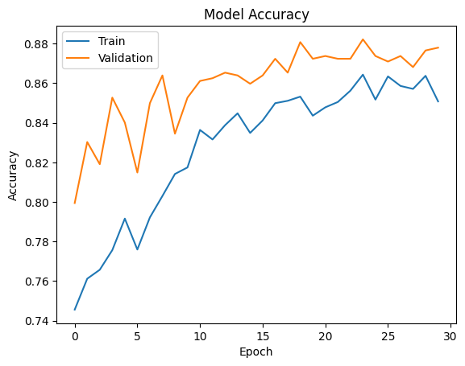

```python
# Creating a plot to visualize model accuracy
plt.plot(history_2.history['accuracy'])
plt.plot(history_2.history['val_accuracy'])
plt.title('Model Accuracy')
plt.ylabel('Accuracy')
plt.xlabel('Epoch')
plt.legend(['Train', 'Validation'], loc='upper left')
plt.show()
```

```python
# Evaluating the model on test data
accuracy = model2.evaluate(X_test_normalized, y_test_encoded, verbose=2)
```

```
23/23 - 0s - loss: 0.3570 - accuracy: 0.8680 - 80ms/epoch - 3ms/step
```

#### Plotting the Confusion Matrix

```python
# Predicting the output probability
y_pred_2=model2.predict(X_test_normalized)
```

```python
# Extracting predicted class labels from probability distribution
y_pred_arg_2=np.argmax(y_pred_2,axis=1)
y_pred_arg_2
```

```
array([ 5, 10,  8, 11, 10,  6,  1,  8, 10, 11,  3,  3,  7,  1,  1,  8,  5,
        9,  3, 11,  6,  5,  5,  9,  5,  8,  8,  4, 11,  0, 10,  5,  2,  5,
        8, 11,  5, 11, 10,  3,  6,  6,  9,  2,  3,  3,  1,  4,  4,  6, 10,
       10, 10,  8,  2,  3,  3,  0,  1,  8,  3,  5,  9,  2,  3,  1,  6, 11,
        4,  3,  3,  5,  6,  8, 10,  2,  6,  8,  3, 10,  6, 11,  8,  1,  5,
        8, 11, 10, 11,  8, 11,  4,  5,  7,  6,  8,  2,  2,  3,  1, 10,  8,
        6,  1, 10,  8,  6,  4,  1,  6,  4, 10, 11,  6,  6,  6,  6,  5,  2,
        3, 11,  1,  8,  3,  2,  6,  5,  0,  0, 11,  6,  1,  9,  5,  3,  1,
        1,  0,  3, 10,  6,  4,  6,  8,  6,  8,  2,  9,  4, 11,  4,  6,  6,
        6,  4,  6,  8, 11,  7,  2,  1,  5,  8, 10,  4,  1, 11,  6,  1,  6,
        9, 10,  3, 11,  5,  8,  3, 11,  2,  1,  8,  5,  8,  6,  1, 10,  5,
        5, 10,  8,  1,  4,  7,  7,  1, 10,  6,  3, 10,  8, 10,  3,  1,  1,
        8,  1, 10,  3,  8,  3, 10,  2,  5,  3,  9, 10,  1,  8,  5, 11,  5,
        5,  8,  8,  8,  1,  6,  7,  5,  5,  8,  4,  2,  8,  0,  2,  9, 10,
        3,  1,  3,  3,  6, 10,  3,  0,  3,  7,  7,  6,  4, 10,  6,  9,  1,
```

[output cut: 27 more lines]

```python
# Extracting true class labels from encoded format
y_test_arg_2=np.argmax(y_test_encoded,axis=1)
y_test_arg_2
```

```
array([ 5, 10,  8, 11, 10,  6,  1,  8, 10, 11,  3,  8,  7,  1,  1,  7,  5,
        9,  3, 11,  6,  5,  5,  9,  5,  8,  8,  4, 11,  0, 10,  5,  2,  5,
        8, 11,  5, 11, 10,  3,  6,  6, 10,  2,  3,  3,  1,  4,  0,  6, 10,
       11, 11,  9,  2,  3,  3,  6,  1,  8,  3,  0,  9,  2,  3,  1,  6, 11,
        4,  3,  3,  5,  6,  9, 10,  2,  6,  8,  3, 10,  6, 11,  8,  1,  4,
        8, 11, 10, 11,  8, 11, 11,  4,  7,  6,  8,  2,  2,  3,  1, 10,  6,
        6,  1, 10,  8,  6,  4,  1,  0,  4, 11, 11,  6,  4,  0,  6,  5,  2,
        3, 11,  1,  8,  3,  2,  6,  5,  6,  0, 11,  6,  1,  9,  5,  3,  1,
        1,  6,  3, 10,  6,  4,  6,  8,  8,  5,  2,  9,  4, 11,  4,  6,  0,
        6,  8,  6,  5, 11,  7,  2,  1,  5,  8, 10,  4,  1, 11,  6,  2,  6,
        9, 10,  3, 11,  5,  8,  3, 11,  2,  1,  8,  5,  8,  6,  1, 10,  5,
        5, 10,  8, 11,  6,  7,  7,  1, 10,  6,  3, 11,  8, 10,  3,  1,  1,
        8,  1, 10,  3,  8,  3, 10,  2,  5,  3,  9, 10,  1,  8,  5, 11,  5,
        5,  9,  0,  8,  1,  6,  4,  5,  5,  8,  4,  2,  8,  0,  2,  9, 10,
        3,  1,  3,  3,  6, 10,  3,  0,  3,  7,  7,  0,  4, 10,  6,  9,  1,
```

[output cut: 27 more lines]

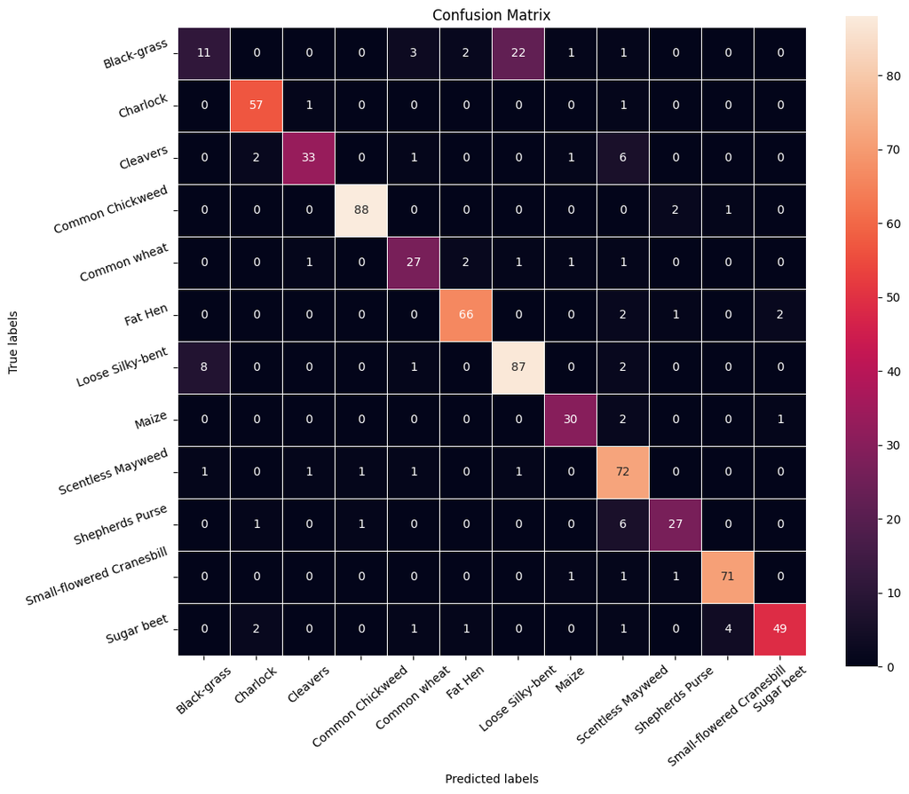

```python
from sklearn import metrics

# Plotting the Confusion Matrix
confusion_matrix = tf.math.confusion_matrix(y_test_arg_2,y_pred_arg_2)
f, ax = plt.subplots(figsize=(12, 10))
sns.heatmap(
    confusion_matrix,
    annot=True,
    linewidths=.4,
    fmt="d",
    square=True,
    ax=ax,
)

# Setting the labels to both the axes
ax.set_xlabel('Predicted labels');ax.set_ylabel('True labels');
ax.set_title('Confusion Matrix');
ax.xaxis.set_ticklabels(list(enc.classes_),rotation=40)
ax.yaxis.set_ticklabels(list(enc.classes_),rotation=20)
plt.show()
```

```python
# plotting the classification report
cr_model_2=metrics.classification_report(y_test_arg_2,y_pred_arg_2)
print(cr_model_2)
```

```
              precision    recall  f1-score   support

           0       0.55      0.28      0.37        40
           1       0.92      0.97      0.94        59
           2       0.92      0.77      0.84        43
           3       0.98      0.97      0.97        91
           4       0.79      0.82      0.81        33
           5       0.93      0.93      0.93        71
           6       0.78      0.89      0.83        98
           7       0.88      0.91      0.90        33
           8       0.76      0.94      0.84        77
           9       0.87      0.77      0.82        35
          10       0.93      0.96      0.95        74
          11       0.94      0.84      0.89        58

    accuracy                           0.87       712
   macro avg       0.85      0.84      0.84       712
weighted avg       0.86      0.87      0.86       712
```

The evaluation metrics obtained from the classification model are quite promising. With an overall accuracy of 87%, the model demonstrates strong performance across multiple metrics. Precision scores are notably high across most classes, indicating that when the model predicts a class, it is correct a substantial portion of the time. Recall scores are also generally high, indicating the model's ability to correctly identify instances of each class from the total true instances. The F1-scores, which balance precision and recall, show robust performance across most classes, further affirming the model's effectiveness in classification tasks. These results suggest that the model trained on this dataset has learned meaningful patterns and can generalize well to unseen data, making it suitable for practical deployment in classification scenarios.

# Model Selection

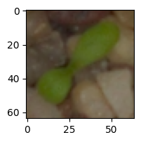

```
Predicted Label ['Scentless Mayweed']
True Label Scentless Mayweed
```

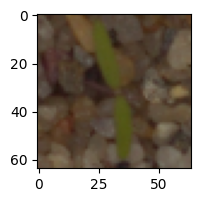

```
Predicted Label ['Fat Hen']
True Label Fat Hen
```

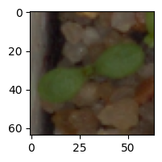

```
Predicted Label ['Scentless Mayweed']
True Label Scentless Mayweed
```

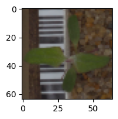

```
Predicted Label ['Fat Hen']
True Label Fat Hen
```

```python
# Visualizing the predicted and correct label of images from test data
plt.figure(figsize=(2,2))
plt.imshow(X_test[2])
plt.show()
## Complete the code to predict the test data using the final model selected
print('Predicted Label', enc.inverse_transform(model2.predict((X_test_normalized[2].reshape(1,64,64,3)))))   # reshaping the input image as we are only trying to predict using a single image
print('True Label', enc.inverse_transform(y_test_encoded)[2])                                               # using inverse_transform() to get the output label from the output vector

plt.figure(figsize=(2,2))
plt.imshow(X_test[33])
plt.show()
## Complete the code to predict the test data using the final model selected
print('Predicted Label', enc.inverse_transform(model2.predict((X_test_normalized[33].reshape(1,64,64,3)))))  # reshaping the input image as we are only trying to predict using a single image
print('True Label', enc.inverse_transform(y_test_encoded)[33])                                              # using inverse_transform() to get the output label from the output vector

plt.figure(figsize=(2,2))
plt.imshow(X_test[59],)
plt.show()
## Complete the code to predict the test data using the final model selected
print('Predicted Label', enc.inverse_transform(model2.predict((X_test_normalized[59].reshape(1,64,64,3)))))  # reshaping the input image as we are only trying to predict using a single image
print('True Label', enc.inverse_transform(y_test_encoded)[59])                                              # using inverse_transform() to get the output label from the output vector

plt.figure(figsize=(2,2))
plt.imshow(X_test[36])
plt.show()
## Complete the code to predict the test data using the final model selected
print('Predicted Label', enc.inverse_transform(model2.predict((X_test_normalized[36].reshape(1,64,64,3)))))  # reshaping the input image as we are only trying to predict using a single image
print('True Label', enc.inverse_transform(y_test_encoded)[36])
```

# Business Insights & Recommendations

**Objectives**

The primary objective of this project was to develop a Convolutional Neural Network (CNN) capable of classifying plant seedlings from images into their respective categories, leveraging AI to streamline the manual classification process.

**Key Findings**

- Model Performance: Model 2 demonstrated superior performance (87% accuracy) over Model 1 (78% accuracy) in accurately classifying a dataset of plant seedling images.
- Impact of Data Imbalance: Addressing dataset imbalances through data augmentation techniques significantly enhanced model performance.
- Optimization Techniques: The implementation of learning rate reduction played a pivotal role in enhancing the model's ability to extract meaningful insights from the data.
- Recommendations: It is recommended to explore additional data augmentation techniques to further improve the model's overall performance. Specifically, investigating the integration of the VGG16 architecture for the convolutional layers could provide substantial benefits.
- Future Model Refinement: Further refinement and evaluation of the model's performance are recommended before considering its deployment for commercial applications.

**Model Observations**

**Recommendations & Conclusions**

Based on the findings and observations from our project on classifying plant seedlings using Convolutional Neural Networks (CNNs), several key recommendations emerge to further enhance model performance and applicability:

Firstly, it is crucial to continue exploring and implementing advanced data augmentation techniques. While our current strategies significantly improved model accuracy by addressing dataset imbalances, further enhancements can be achieved by experimenting with more sophisticated augmentation methods. Techniques such as CutMix, MixUp, and AutoAugment could potentially provide additional variations to augment data, thereby enriching the model's ability to generalize across diverse instances of plant seedlings.

Secondly, the integration of transfer learning, particularly leveraging established architectures like VGG16 for the convolutional layers, should be thoroughly investigated. Transfer learning allows models to leverage pre-trained networks on large datasets, extracting useful features that can enhance performance on our specific task with potentially less labeled data required for training. This approach not only accelerates model convergence but also enhances its capability to handle intricate patterns and nuances within the seedling images.

Furthermore, continuous model refinement through hyperparameter tuning remains pivotal. Exploring a broader range of hyperparameters such as learning rates, batch sizes, and regularization techniques can optimize model generalization and resilience against overfitting. Employing techniques like grid search or Bayesian optimization can systematically explore these hyperparameter spaces to identify optimal configurations that maximize model efficacy.

Moreover, to ensure robust model deployment and scalability, rigorous validation and testing across diverse datasets and environmental conditions are recommended. This includes evaluating the model's performance on unseen data from different geographic regions or under varying lighting and environmental conditions. Such validations will enhance confidence in the model's reliability and generalizability in real-world applications.

Lastly, establishing a framework for continual model monitoring and updates post-deployment is essential. This involves setting up metrics for ongoing performance evaluation and establishing protocols for retraining the model with new data to maintain accuracy over time. Regular updates will ensure that the model adapts to evolving patterns and trends in plant seedling characteristics, thereby sustaining its relevance and effectiveness in practical applications.

In conclusion, these recommendations are aimed at not only improving the current model's accuracy and robustness but also at establishing a foundation for continuous enhancement and adaptation to meet future challenges in plant seedling classification tasks. By implementing these strategies, we aim to elevate the efficacy and reliability of AI-powered solutions in agricultural automation and biodiversity monitoring.